# Act11

2026-07-06

A2: Read in the species data and remove unnecessary rows with NAs.

```r
df11 <- read.csv("herpetozoa-033-095-s001.csv")
good <- complete.cases(df11)
df11 <- df11[good, ]
```

```r
library(terra)
elev <- rast("wc2.1_10m_elev.tif")
```

A4: From the species data, subset the longitude and latitude coordinates. Then convert the coordinates to a spatial vector using the “vect” function from the “terra” package.

```r
coord <- vect(df11, geom = c("Long", "Lat"))
```

A5: Using the converted coordinates, extract elevation data for each point with the “extract” function in the “terra” package. The extracted data will have two columns: “ID” and “Band_1.” The “Band_1” column contains the elevation.

```r
extractElev <- extract(elev, coord)
```

A6: Subset the species data to retain only the species richness column (SPPTotal). Then combine this column with the extracted elevation. Rename “Band_1” to “elevation.”

```r
df11SPP <- data.frame(
  SPPTotal = df11$SPPTotal,
  elevation = extractElev[, 2]
)
```

```r
x <- df11SPP$elevation
y <- df11SPP$SPPTotal
xbar <- mean(x)
ybar <- mean(y)
b <- sum((x - xbar) * (y - ybar)) /
     sum((x - xbar)^2)
a <- ybar - b * xbar
cat("Regression Equation:\n")
```

```
## Regression Equation:
```

```r
cat("y =", round(a,3), "+", round(b,3), "x\n")
```

```
## y = 5.579 + -0.007 x
```

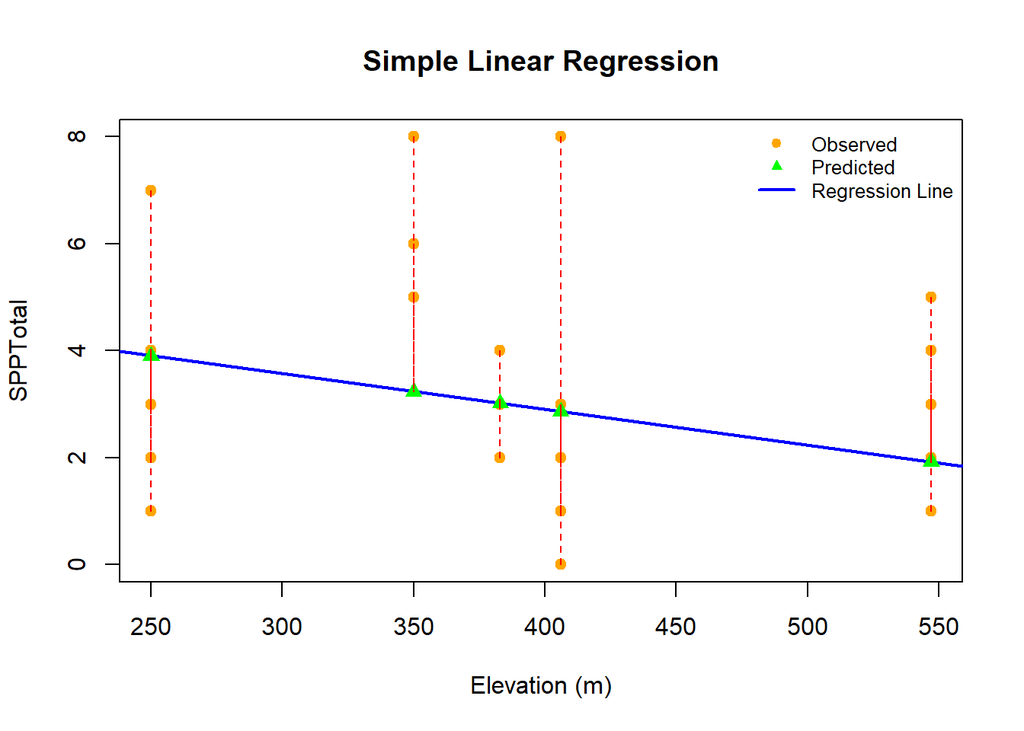

```r
yhat <- a + b * x
plot(x, y,
     pch = 19,
     col = "orange",
     xlab = "Elevation (m)",
     ylab = "SPPTotal",
     main = "Simple Linear Regression")
abline(a, b,
       col = "blue",
       lwd = 2)
points(x, yhat,
       pch = 17,      # Triangle
       col = "green",
       cex = 1.2)
segments(x0 = x, y0 = y,
         x1 = x, y1 = yhat,
         lty = 2,
         col = "red")
legend("topright",
       legend = c("Observed", "Predicted", "Regression Line"),
       pch = c(19, 17, NA),
       lty = c(NA, NA, 1),
       col = c("orange", "green", "blue"),
       lwd = c(NA, NA, 2),
       bty = "n",
       cex = 0.8)
```

B1: Read in both annual precipitation and temperature data and extract the data following the instructions from A4–5.

```r
preci <- rast("annual_precipitation.tif")
temp <- rast("annual_temperature.tif")
extractpreci <- extract(preci, coord)
extracttemp <- extract(temp, coord)
```

B2: Combine the extracted data with the species and elevation data into a single dataframe.

```r
df11Ult <- data.frame(
  SPPTotal = df11$SPPTotal,
  elevation = extractElev[, 2],
  precipitation = extractpreci[, 2],
  temperature = extracttemp[, 2]
)
```

B3: Perform multiple linear regression using the “lm” function.

```r
x <- df11Ult$elevation
x1 <- df11Ult$precipitation
x2 <- df11Ult$temperature
y <- df11Ult$SPPTotal
model <- lm(y ~ x + x1 + x2)
coef(model)
```

```
##  (Intercept)            x           x1           x2
## 96.001515631 -0.006441861 -0.030632433 -1.500715354
```

```r
a <- coef(model)[1]
b <- coef(model)[2]
c <- coef(model)[3]
d <- coef(model)[4]
cat("Regression Equation:\n")
```

```
## Regression Equation:
```

```r
cat("y =", round(a, 3), "+", round(b, 3), "x +", round(c, 3), "x1 +", round(d, 3), "x2\n\n")
```

```
## y = 96.002 + -0.006 x + -0.031 x1 + -1.501 x2
```

```r
yhat <- predict(model)
residuals <- residuals(model)
summary(model)$r.squared
```

```
## [1] 0.3658037
```

```r
results <- data.frame(
  elevation = x,
  precipitation = x1,
  temperature = x2,
  Observed = y,
  Predicted = round(yhat,2),
  Residual = round(residuals,2)
)
print(results)
```

```
##    elevation precipitation temperature Observed Predicted Residual
## 1        406          1714    26.23333        0      1.51    -1.51
## 2        406          1714    26.23333        0      1.51    -1.51
## 3        406          1678    26.98750        0      1.48    -1.48
## 4        406          1678    26.98750        0      1.48    -1.48
## 5        406          1788    24.94583        1      1.18    -0.18
## 6        406          1788    24.94583        1      1.18    -0.18
## 7        406          1771    25.11667        1      1.44    -0.44
## 8        547          1883    22.57500        1      0.92     0.08
## 9        547          1780    24.18333        1      1.66    -0.66
## 10       547          1684    25.43750        1      2.72    -1.72
## 11       547          1684    25.43750        1      2.72    -1.72
## 12       547          1734    24.69167        1      2.31    -1.31
## 13       547          1754    24.42500        1      2.09    -1.09
## 14       547          1803    23.60000        1      1.83    -0.83
```

[output cut: 35 more lines]

```r
summary(model)
```

```
##
## Call:
## lm(formula = y ~ x + x1 + x2)
##
## Residuals:
##     Min      1Q  Median      3Q     Max
## -3.0163 -1.3060 -0.1787  0.6840  6.4866
##
## Coefficients:
##              Estimate Std. Error t value Pr(>|t|)
## (Intercept) 96.001516  26.651584   3.602 0.000785 ***
## x           -0.006442   0.002699  -2.387 0.021265 *
## x1          -0.030632   0.007769  -3.943 0.000278 ***
## x2          -1.500715   0.550024  -2.728 0.009045 **
## ---
## Signif. codes:  0 '***' 0.001 '**' 0.01 '*' 0.05 '.' 0.1 ' ' 1
##
## Residual standard error: 1.725 on 45 degrees of freedom
## Multiple R-squared:  0.3658, Adjusted R-squared:  0.3235
## F-statistic: 8.652 on 3 and 45 DF,  p-value: 0.0001209
```

B4: Which relationship is statistically significant? The relationship of species diversity with 3 conditions: elevation, precipitation, and temperature, are all statistically significant.